# PSSeg: Parent-Specifc copy number segmentation

M. Pierre-Jean, G. Rigaill, P. Neuvial

2019-01-11

Please see Appendix for citing `jointseg`.

## Preparing data to be segmented

`PSSeg` requires normalized copy number signals, in the form of total copy number estimates and allele B fractions for tumor, the (germline) genotype of SNP. Loci are assumed to come from a single chromosome and to be ordered by genomic position.

For illustration, we show of such a data set may be created from real data. We use data from a public SNP array data set, which is distributed in the `acnr` package (on which the `jointseg` package depends).

```r
data <- acnr::loadCnRegionData(dataSet="GSE29172", tumorFraction=1)
str(data)
```

```
## 'data.frame':    40000 obs. of  7 variables:
##  $ c          : num  0.909 0.859 1.304 0.647 0.947 ...
##  $ b          : num  NaN NaN NaN NaN NaN NaN NaN -0.035 NaN NaN ...
##  $ genotype   : num  NA NA NA NA NA NA NA 0 NA NA ...
##  $ bT         : num  NaN NaN NaN NaN NaN NaN NaN 0.161 NaN NaN ...
##  $ bN         : num  NaN NaN NaN NaN NaN NaN NaN 0.196 NaN NaN ...
##  $ region     : chr  "(0,1)" "(0,1)" "(0,1)" "(0,1)" ...
##  $ cellularity: num  1 1 1 1 1 1 1 1 1 1 ...
```

This data set consists of copy number signals from 8 types of genomic regions:

```r
table(data[["region"]])
```

```
##
## (0,1) (0,2) (0,3) (1,1) (1,2) (1,3) (2,2) (2,3)
##  5000  5000  5000  5000  5000  5000  5000  5000
```

These regions are coded as $(C_1,C_2)$, where $C_1$ denotes the minor copy number and $C_2$ denotes the major copy number, i.e. the smallest and the largest of the two parental copy numbers (see e.g. [4] for more detailed definitions). For example, $(1,1)$ corresponds to a normal state, $(0,1)$ to an hemizygous deletion, $(1,2)$ to a single copy gain and $(0,2)$ to a copy-neutral LOH (loss of heterozygosity).

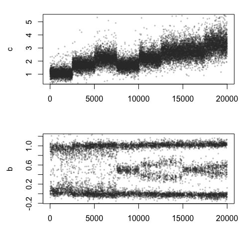

```r
idxs <- sort(sample(1:nrow(data), 2e4))
plotSeg(data[idxs, ])
```

```r
K <- 10
bkp <- c(408,1632,3905, 5890,6709, 10481, 12647,14089,17345,18657)
len <- 2e4
sim <- getCopyNumberDataByResampling(len, bkp=bkp, minLength=500, regData=data)
datS <- sim$profile
str(datS)
```

```
## 'data.frame':    20000 obs. of  7 variables:
##  $ c          : num  1.92 1.66 1.67 1.74 1.66 ...
##  $ b          : num  -0.005 NaN 0.933 NaN NaN NaN 0.961 0.959 NaN NaN ...
##  $ genotype   : num  0 NA 1 NA NA NA 0.5 1 NA NA ...
##  $ bT         : num  0.041 NaN 0.699 NaN NaN NaN 0.966 0.776 NaN NaN ...
##  $ bN         : num  0.046 NaN 0.766 NaN NaN NaN 0.56 0.817 NaN NaN ...
##  $ region     : chr  "(0,2)" "(0,2)" "(0,2)" "(0,2)" ...
##  $ cellularity: num  1 1 1 1 1 1 1 1 1 1 ...
```

The resulting copy-number profile is plotted below.

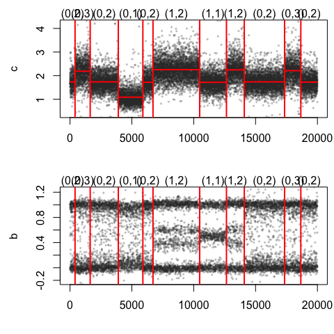

```r
plotSeg(datS, sim$bkp)
```

## Preprocessing

We advise the following (typical) preprocessing before segmentation: * $\log$-transform total copy numbers in order to stabilize their variance; this step improve segmentation results for all methods.

```r
datS$c <- log2(datS$c)-1
```

- smooth single point outliers as suggested by [5] This step is controlled by the `dropOutliers` option in the `PSSeg` function, which internally calls the `smooth.CNA` function of the `DNAcopy` package. The default value for this option is `TRUE`.
- convert allelic ratios to (unimodal) decrease in heterozygosity ($d$), as initially suggested by [7]. This step is performed internally in the `PSSeg` function.

## PSSeg segmentation using RBS

We can now use the `PSSeg` function to segment signals. The method consists in three steps:

- run a fast (yet approximate) segmentation on these signals in order to obtain a set of (at most hundreds of) candidate change points. This is done using Recursive Binary Segmentation (RBS [2]);
- prune the obtained set of change points using dynamic programming [1]
- select the best number of change points using a model selection criterion proposed by [3]

## Initial segmentation and pruning

```r
resRBS <- PSSeg(data=datS, K=2*K, method="RBS", stat=c("c", "d"), profile=TRUE)
```

Note that this is fast:

```r
resRBS$prof[, "time"]
```

```
## segmentation        dpseg
##         0.06         0.00
```

## Plot segmented profile

To plot the PSSeg segmentation results together with the true breakpoints, do :

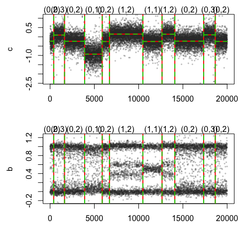

```r
plotSeg(datS, list(true=sim$bkp, est=resRBS$bestBkp))
```

## Results evaluation

The `PSSeg` function returns the original segmentation (by `RBS`), the result of the pruning step, and the best model (among those selected by dynamic programming) according to the criterion proposed by [3].

```r
print(getTpFp(resRBS$bestBkp, sim$bkp, tol=5))
```

```
## TP FP
##  9  1
```

Obviously, this performance measure depends on the chosen tolerance:

```r
perf <- sapply(0:10, FUN=function(tol) {
    getTpFp(resRBS$bestBkp, sim$bkp, tol=tol,relax = -1)
})
print(perf)
```

```
##    [,1] [,2] [,3] [,4] [,5] [,6] [,7] [,8] [,9] [,10] [,11]
## TP    4    7    7    9    9    9   10   10   10    10    10
## FP    6    3    3    1    1    1    0    0    0     0     0
```

## Citing `jointseg`

```r
citation("jointseg")
```

[output not shown]

## References

[1] Bellman, Richard. 1961. “On the Approximation of Curves by Line Segments Using Dynamic Programming.” Communications of the ACM 4 (6). ACM: 284.

[2] Gey, Servane, et al. 2008. “Using CART to Detect Multiple Change Points in the Mean for Large Sample.” https://hal.archives-ouvertes.fr/hal-00327146.

[3] Lebarbier, E. 2005. “Detecting Multiple Change-Points in the Mean of Gaussian Process by Model Selection.” Signal Processing 85 (4): 717-36.

[4] Neuvial, Pierre, et al. 2011. “Statistical Analysis of Single Nucleotide Polymorphism Microarrays in Cancer Studies.” In Handbook of Statistical Bioinformatics, 1st ed. Springer Handbooks of Computational Statistics. Springer.

[5] Olshen, A B, et al.. 2004. “Circular Binary Segmentation for the Analysis of Array-Based DNA Copy Number Data.” Biostatistics 5 (4): 557-72.

[6] Pierre-Jean, Morgane, et al. 2015. “Performance Evaluation of DNA Copy Number Segmentation Methods.” Briefings in Bioinformatics, no. 4: 600-615.

[7] Staaf, Johan, et al. 2008. “Segmentation-Based Detection of Allelic Imbalance and Loss-of-Heterozygosity in Cancer Cells Using Whole Genome SNP Arrays.” Genome Biology 9 (9). BioMed Central: R136.